# Data Science Project

#### By using this method, we can have to choose the target class because both attributes Summary and PrecipType can be our target class.

#### Now lets move to Encoding Method.

## Encoding Technique

Now use old data to perform encoding.

```python
data.head()
```

| Formatted Date | Summary | Precip Type | Temperature (C) | Apparent Temperature (C) | Humidity | Wind Speed (km/h) | Wind Bearing (degrees) | Visibility (km) | Pressure (millibars) | Binned_Humidity | Binned_Wind_Speed_(km/h) |
| --- | --- | --- | --- | --- | --- | --- | --- | --- | --- | --- | --- |
| 2006-03-31 22:00:00+00:00 | Partly Cloudy | rain | 9.472222 | 7.388889 | 0.89 | 14.1197 | 251.0 | 15.8263 | 1015.13 | 2 | 2 |
| 2006-03-31 23:00:00+00:00 | Partly Cloudy | rain | 9.355556 | 7.227778 | 0.86 | 14.2646 | 259.0 | 15.8263 | 1015.63 | 2 | 2 |
| 2006-04-01 00:00:00+00:00 | Mostly Cloudy | rain | 9.377778 | 9.377778 | 0.89 | 3.9284 | 204.0 | 14.9569 | 1015.94 | 2 | 1 |
| 2006-04-01 01:00:00+00:00 | Partly Cloudy | rain | 8.288889 | 5.944444 | 0.83 | 14.1036 | 269.0 | 15.8263 | 1016.41 | 2 | 2 |
| 2006-04-01 02:00:00+00:00 | Mostly Cloudy | rain | 8.755556 | 6.977778 | 0.83 | 11.0446 | 259.0 | 15.8263 | 1016.51 | 2 | 2 |

```python
for var in data.columns:
    if (data[var].dtype) == object:
        print(str(var) +": \t"+ str((data[var].dtype)))
```

```
Summary: 	object
Precip Type: 	object
```

### Summary

```python
data['Summary'].value_counts()
```

```
Partly Cloudy    31733
Mostly Cloudy    28094
Overcast         16597
Clear            10890
Foggy             7148
Other             1991
Name: Summary, dtype: int64
```

```
<BarContainer object of 6 artists>
```

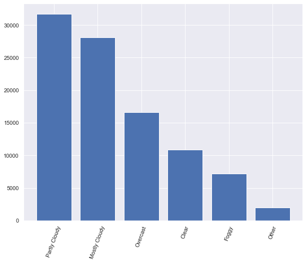

```python
plt.subplots(figsize=(10, 8))
plt.xticks(rotation=70)
plt.bar(data['Summary'].value_counts().index, ((data['Summary'].value_counts().values)))
```

```
 [Text(0.5629184617196125, 0.9450517475012812, 'Partly Cloudy'),
 [Text(0.3070464336652431, 0.5154827713643351, '32.90%'),
```

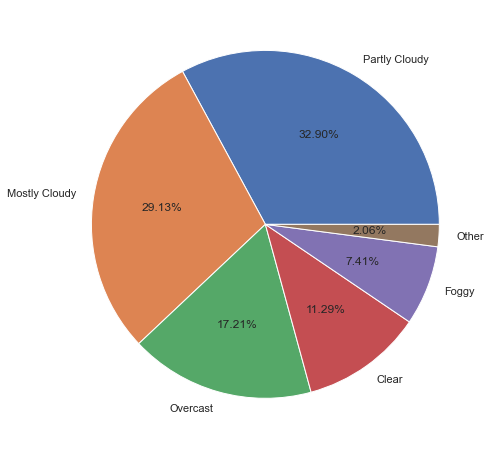

```python
plt.subplots(figsize=(10, 8))
plt.pie((data['Summary'].value_counts().values), labels=data['Summary'].value_counts().index, autopct='%.2f%%')
```

Now we use **Dummy Encoding Technique** to convert them into numeric values.

### Dummy Encoding

```python
data2 = pd.get_dummies(data,columns=['Summary'],prefix='Summary', drop_first=True)
data2.head()
```

| Formatted Date | Precip Type | Temperature (C) | Apparent Temperature (C) | Humidity | Wind Speed (km/h) | Wind Bearing (degrees) | Visibility (km) | Pressure (millibars) | Binned_Humidity | Binned_Wind_Speed_(km/h) | Summary_Foggy | Summary_Mostly Cloudy | Summary_Other | Summary_Overcast | Summary_Partly Cloudy |
| --- | --- | --- | --- | --- | --- | --- | --- | --- | --- | --- | --- | --- | --- | --- | --- |
| 2006-03-31 22:00:00+00:00 | rain | 9.472222 | 7.388889 | 0.89 | 14.1197 | 251.0 | 15.8263 | 1015.13 | 2 | 2 | 0 | 0 | 0 | 0 | 1 |
| 2006-03-31 23:00:00+00:00 | rain | 9.355556 | 7.227778 | 0.86 | 14.2646 | 259.0 | 15.8263 | 1015.63 | 2 | 2 | 0 | 0 | 0 | 0 | 1 |
| 2006-04-01 00:00:00+00:00 | rain | 9.377778 | 9.377778 | 0.89 | 3.9284 | 204.0 | 14.9569 | 1015.94 | 2 | 1 | 0 | 1 | 0 | 0 | 0 |
| 2006-04-01 01:00:00+00:00 | rain | 8.288889 | 5.944444 | 0.83 | 14.1036 | 269.0 | 15.8263 | 1016.41 | 2 | 2 | 0 | 0 | 0 | 0 | 1 |
| 2006-04-01 02:00:00+00:00 | rain | 8.755556 | 6.977778 | 0.83 | 11.0446 | 259.0 | 15.8263 | 1016.51 | 2 | 2 | 0 | 1 | 0 | 0 | 0 |

By using Dummy Encoding, we got the less value column. So we use One-Hot Encoding and then delete Summary_Other Column.

### One-Hot Encoding

```python
data = pd.get_dummies(data,columns=['Summary'],prefix='Summary')
data.head()
```

| Formatted Date | Precip Type | Temperature (C) | Apparent Temperature (C) | Humidity | Wind Speed (km/h) | Wind Bearing (degrees) | Visibility (km) | Pressure (millibars) | Binned_Humidity | Binned_Wind_Speed_(km/h) | Summary_Clear | Summary_Foggy | Summary_Mostly Cloudy | Summary_Other | Summary_Overcast | Summary_Partly Cloudy |
| --- | --- | --- | --- | --- | --- | --- | --- | --- | --- | --- | --- | --- | --- | --- | --- | --- |
| 2006-03-31 22:00:00+00:00 | rain | 9.472222 | 7.388889 | 0.89 | 14.1197 | 251.0 | 15.8263 | 1015.13 | 2 | 2 | 0 | 0 | 0 | 0 | 0 | 1 |
| 2006-03-31 23:00:00+00:00 | rain | 9.355556 | 7.227778 | 0.86 | 14.2646 | 259.0 | 15.8263 | 1015.63 | 2 | 2 | 0 | 0 | 0 | 0 | 0 | 1 |
| 2006-04-01 00:00:00+00:00 | rain | 9.377778 | 9.377778 | 0.89 | 3.9284 | 204.0 | 14.9569 | 1015.94 | 2 | 1 | 0 | 0 | 1 | 0 | 0 | 0 |
| 2006-04-01 01:00:00+00:00 | rain | 8.288889 | 5.944444 | 0.83 | 14.1036 | 269.0 | 15.8263 | 1016.41 | 2 | 2 | 0 | 0 | 0 | 0 | 0 | 1 |
| 2006-04-01 02:00:00+00:00 | rain | 8.755556 | 6.977778 | 0.83 | 11.0446 | 259.0 | 15.8263 | 1016.51 | 2 | 2 | 0 | 0 | 1 | 0 | 0 | 0 |

```python
data.drop(['Summary_Other'],axis=1,inplace=True)
data.head()
```

| Formatted Date | Precip Type | Temperature (C) | Apparent Temperature (C) | Humidity | Wind Speed (km/h) | Wind Bearing (degrees) | Visibility (km) | Pressure (millibars) | Binned_Humidity | Binned_Wind_Speed_(km/h) | Summary_Clear | Summary_Foggy | Summary_Mostly Cloudy | Summary_Overcast | Summary_Partly Cloudy |
| --- | --- | --- | --- | --- | --- | --- | --- | --- | --- | --- | --- | --- | --- | --- | --- |
| 2006-03-31 22:00:00+00:00 | rain | 9.472222 | 7.388889 | 0.89 | 14.1197 | 251.0 | 15.8263 | 1015.13 | 2 | 2 | 0 | 0 | 0 | 0 | 1 |
| 2006-03-31 23:00:00+00:00 | rain | 9.355556 | 7.227778 | 0.86 | 14.2646 | 259.0 | 15.8263 | 1015.63 | 2 | 2 | 0 | 0 | 0 | 0 | 1 |
| 2006-04-01 00:00:00+00:00 | rain | 9.377778 | 9.377778 | 0.89 | 3.9284 | 204.0 | 14.9569 | 1015.94 | 2 | 1 | 0 | 0 | 1 | 0 | 0 |
| 2006-04-01 01:00:00+00:00 | rain | 8.288889 | 5.944444 | 0.83 | 14.1036 | 269.0 | 15.8263 | 1016.41 | 2 | 2 | 0 | 0 | 0 | 0 | 1 |
| 2006-04-01 02:00:00+00:00 | rain | 8.755556 | 6.977778 | 0.83 | 11.0446 | 259.0 | 15.8263 | 1016.51 | 2 | 2 | 0 | 0 | 1 | 0 | 0 |

### Precip Type

```python
data['Precip Type'].value_counts()
```

```
rain    85741
snow    10712
Name: Precip Type, dtype: int64
```

```
<BarContainer object of 2 artists>
```

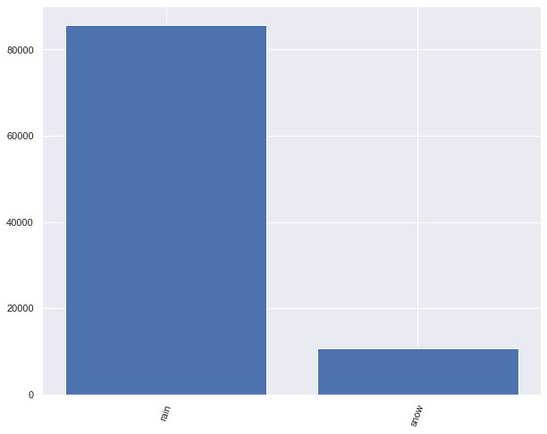

```python
plt.subplots(figsize=(10, 8))
plt.xticks(rotation=70)
plt.bar(data['Precip Type'].value_counts().index, ((data['Precip Type'].value_counts().values)))
```

```
 [Text(-1.0337231675331422, 0.376053736725548, 'rain'),
 [Text(-0.5638490004726229, 0.20512022003211705, '88.89%'),
```

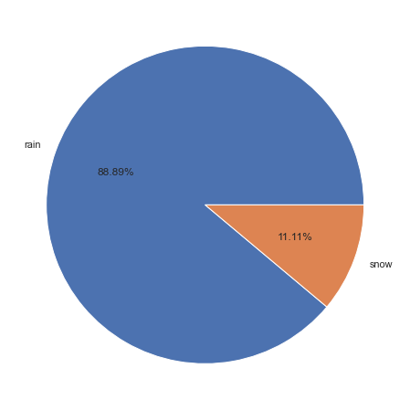

```python
plt.subplots(figsize=(10, 8))
plt.pie((data['Precip Type'].value_counts().values), labels=data['Precip Type'].value_counts().index, autopct='%.2f%%')
```

Now we use **Dummy Encoding** Technique to convert them into numeric values.

```python
data2 = pd.get_dummies(data,columns=['Precip Type'],prefix='Precip_Type', drop_first=True)
data2.head()
```

| Formatted Date | Temperature (C) | Apparent Temperature (C) | Humidity | Wind Speed (km/h) | Wind Bearing (degrees) | Visibility (km) | Pressure (millibars) | Binned_Humidity | Binned_Wind_Speed_(km/h) | Summary_Clear | Summary_Foggy | Summary_Mostly Cloudy | Summary_Overcast | Summary_Partly Cloudy | Precip_Type_snow |
| --- | --- | --- | --- | --- | --- | --- | --- | --- | --- | --- | --- | --- | --- | --- | --- |
| 2006-03-31 22:00:00+00:00 | 9.472222 | 7.388889 | 0.89 | 14.1197 | 251.0 | 15.8263 | 1015.13 | 2 | 2 | 0 | 0 | 0 | 0 | 1 | 0 |
| 2006-03-31 23:00:00+00:00 | 9.355556 | 7.227778 | 0.86 | 14.2646 | 259.0 | 15.8263 | 1015.63 | 2 | 2 | 0 | 0 | 0 | 0 | 1 | 0 |
| 2006-04-01 00:00:00+00:00 | 9.377778 | 9.377778 | 0.89 | 3.9284 | 204.0 | 14.9569 | 1015.94 | 2 | 1 | 0 | 0 | 1 | 0 | 0 | 0 |
| 2006-04-01 01:00:00+00:00 | 8.288889 | 5.944444 | 0.83 | 14.1036 | 269.0 | 15.8263 | 1016.41 | 2 | 2 | 0 | 0 | 0 | 0 | 1 | 0 |
| 2006-04-01 02:00:00+00:00 | 8.755556 | 6.977778 | 0.83 | 11.0446 | 259.0 | 15.8263 | 1016.51 | 2 | 2 | 0 | 0 | 1 | 0 | 0 | 0 |

Again By using Dummy Encoding, we got the less value column. So we use One-Hot Encoding and then delete Precip_Type_snow Column.

### One-Hot Encoding

```python
data = pd.get_dummies(data,columns=['Precip Type'],prefix='Precip_Type')
data.head()
```

| Formatted Date | Temperature (C) | Apparent Temperature (C) | Humidity | Wind Speed (km/h) | Wind Bearing (degrees) | Visibility (km) | Pressure (millibars) | Binned_Humidity | Binned_Wind_Speed_(km/h) | Summary_Clear | Summary_Foggy | Summary_Mostly Cloudy | Summary_Overcast | Summary_Partly Cloudy | Precip_Type_rain | Precip_Type_snow |
| --- | --- | --- | --- | --- | --- | --- | --- | --- | --- | --- | --- | --- | --- | --- | --- | --- |
| 2006-03-31 22:00:00+00:00 | 9.472222 | 7.388889 | 0.89 | 14.1197 | 251.0 | 15.8263 | 1015.13 | 2 | 2 | 0 | 0 | 0 | 0 | 1 | 1 | 0 |
| 2006-03-31 23:00:00+00:00 | 9.355556 | 7.227778 | 0.86 | 14.2646 | 259.0 | 15.8263 | 1015.63 | 2 | 2 | 0 | 0 | 0 | 0 | 1 | 1 | 0 |
| 2006-04-01 00:00:00+00:00 | 9.377778 | 9.377778 | 0.89 | 3.9284 | 204.0 | 14.9569 | 1015.94 | 2 | 1 | 0 | 0 | 1 | 0 | 0 | 1 | 0 |
| 2006-04-01 01:00:00+00:00 | 8.288889 | 5.944444 | 0.83 | 14.1036 | 269.0 | 15.8263 | 1016.41 | 2 | 2 | 0 | 0 | 0 | 0 | 1 | 1 | 0 |
| 2006-04-01 02:00:00+00:00 | 8.755556 | 6.977778 | 0.83 | 11.0446 | 259.0 | 15.8263 | 1016.51 | 2 | 2 | 0 | 0 | 1 | 0 | 0 | 1 | 0 |

```python
data.drop(['Precip_Type_snow'],axis=1,inplace=True)
data.head()
```

| Formatted Date | Temperature (C) | Apparent Temperature (C) | Humidity | Wind Speed (km/h) | Wind Bearing (degrees) | Visibility (km) | Pressure (millibars) | Binned_Humidity | Binned_Wind_Speed_(km/h) | Summary_Clear | Summary_Foggy | Summary_Mostly Cloudy | Summary_Overcast | Summary_Partly Cloudy | Precip_Type_rain |
| --- | --- | --- | --- | --- | --- | --- | --- | --- | --- | --- | --- | --- | --- | --- | --- |
| 2006-03-31 22:00:00+00:00 | 9.472222 | 7.388889 | 0.89 | 14.1197 | 251.0 | 15.8263 | 1015.13 | 2 | 2 | 0 | 0 | 0 | 0 | 1 | 1 |
| 2006-03-31 23:00:00+00:00 | 9.355556 | 7.227778 | 0.86 | 14.2646 | 259.0 | 15.8263 | 1015.63 | 2 | 2 | 0 | 0 | 0 | 0 | 1 | 1 |
| 2006-04-01 00:00:00+00:00 | 9.377778 | 9.377778 | 0.89 | 3.9284 | 204.0 | 14.9569 | 1015.94 | 2 | 1 | 0 | 0 | 1 | 0 | 0 | 1 |
| 2006-04-01 01:00:00+00:00 | 8.288889 | 5.944444 | 0.83 | 14.1036 | 269.0 | 15.8263 | 1016.41 | 2 | 2 | 0 | 0 | 0 | 0 | 1 | 1 |
| 2006-04-01 02:00:00+00:00 | 8.755556 | 6.977778 | 0.83 | 11.0446 | 259.0 | 15.8263 | 1016.51 | 2 | 2 | 0 | 0 | 1 | 0 | 0 | 1 |

#### By using Encoding Technique, our dataset target class can be "Precip_Type_rain".

We have cleaned our data by using two methods. Now we have two different datasets.  
1- data  
In this dataset, we change object attributes to numeric form by using encoding techniques.  
**2- df1**  
In this dataset, we change object attributes to numeric form by using Pandas Catigorical Codes.

## data

```python
data.head()
```

| Formatted Date | Temperature (C) | Apparent Temperature (C) | Humidity | Wind Speed (km/h) | Wind Bearing (degrees) | Visibility (km) | Pressure (millibars) | Binned_Humidity | Binned_Wind_Speed_(km/h) | Summary_Clear | Summary_Foggy | Summary_Mostly Cloudy | Summary_Overcast | Summary_Partly Cloudy | Precip_Type_rain |
| --- | --- | --- | --- | --- | --- | --- | --- | --- | --- | --- | --- | --- | --- | --- | --- |
| 2006-03-31 22:00:00+00:00 | 9.472222 | 7.388889 | 0.89 | 14.1197 | 251.0 | 15.8263 | 1015.13 | 2 | 2 | 0 | 0 | 0 | 0 | 1 | 1 |
| 2006-03-31 23:00:00+00:00 | 9.355556 | 7.227778 | 0.86 | 14.2646 | 259.0 | 15.8263 | 1015.63 | 2 | 2 | 0 | 0 | 0 | 0 | 1 | 1 |
| 2006-04-01 00:00:00+00:00 | 9.377778 | 9.377778 | 0.89 | 3.9284 | 204.0 | 14.9569 | 1015.94 | 2 | 1 | 0 | 0 | 1 | 0 | 0 | 1 |
| 2006-04-01 01:00:00+00:00 | 8.288889 | 5.944444 | 0.83 | 14.1036 | 269.0 | 15.8263 | 1016.41 | 2 | 2 | 0 | 0 | 0 | 0 | 1 | 1 |
| 2006-04-01 02:00:00+00:00 | 8.755556 | 6.977778 | 0.83 | 11.0446 | 259.0 | 15.8263 | 1016.51 | 2 | 2 | 0 | 0 | 1 | 0 | 0 | 1 |

```python
data.info()
```

```
<class 'pandas.core.frame.DataFrame'>
DatetimeIndex: 96453 entries, 2006-03-31 22:00:00+00:00 to 2016-09-09 21:00:00+00:00
Data columns (total 15 columns):
 #   Column                    Non-Null Count  Dtype
---  ------                    --------------  -----
 0   Temperature (C)           96453 non-null  float64
 1   Apparent Temperature (C)  96453 non-null  float64
 2   Humidity                  96453 non-null  float64
 3   Wind Speed (km/h)         96453 non-null  float64
 4   Wind Bearing (degrees)    96453 non-null  float64
 5   Visibility (km)           96453 non-null  float64
 6   Pressure (millibars)      96453 non-null  float64
 7   Binned_Humidity           96453 non-null  category
 8   Binned_Wind_Speed_(km/h)  96453 non-null  category
 9   Summary_Clear             96453 non-null  uint8
 10  Summary_Foggy             96453 non-null  uint8
 11  Summary_Mostly Cloudy     96453 non-null  uint8
 12  Summary_Overcast          96453 non-null  uint8
 13  Summary_Partly Cloudy     96453 non-null  uint8
 14  Precip_Type_rain          96453 non-null  uint8
dtypes: category(2), float64(7), uint8(6)
memory usage: 9.1 MB
```

```python
data.shape
```

```
(96453, 15)
```

## df1

```python
df1.head()
```

| Formatted Date | Summary | Precip Type | Temperature (C) | Apparent Temperature (C) | Humidity | Wind Speed (km/h) | Wind Bearing (degrees) | Visibility (km) | Pressure (millibars) | Binned_Humidity | Binned_Wind_Speed_(km/h) |
| --- | --- | --- | --- | --- | --- | --- | --- | --- | --- | --- | --- |
| 2006-03-31 22:00:00+00:00 | 5 | 0 | 9.472222 | 7.388889 | 0.89 | 14.1197 | 251.0 | 15.8263 | 1015.13 | 2 | 2 |
| 2006-03-31 23:00:00+00:00 | 5 | 0 | 9.355556 | 7.227778 | 0.86 | 14.2646 | 259.0 | 15.8263 | 1015.63 | 2 | 2 |
| 2006-04-01 00:00:00+00:00 | 2 | 0 | 9.377778 | 9.377778 | 0.89 | 3.9284 | 204.0 | 14.9569 | 1015.94 | 2 | 1 |
| 2006-04-01 01:00:00+00:00 | 5 | 0 | 8.288889 | 5.944444 | 0.83 | 14.1036 | 269.0 | 15.8263 | 1016.41 | 2 | 2 |
| 2006-04-01 02:00:00+00:00 | 2 | 0 | 8.755556 | 6.977778 | 0.83 | 11.0446 | 259.0 | 15.8263 | 1016.51 | 2 | 2 |

```python
df1.info()
```

```
<class 'pandas.core.frame.DataFrame'>
DatetimeIndex: 96453 entries, 2006-03-31 22:00:00+00:00 to 2016-09-09 21:00:00+00:00
Data columns (total 11 columns):
 #   Column                    Non-Null Count  Dtype
---  ------                    --------------  -----
 0   Summary                   96453 non-null  int8
 1   Precip Type               96453 non-null  int8
 2   Temperature (C)           96453 non-null  float64
 3   Apparent Temperature (C)  96453 non-null  float64
 4   Humidity                  96453 non-null  float64
 5   Wind Speed (km/h)         96453 non-null  float64
 6   Wind Bearing (degrees)    96453 non-null  float64
 7   Visibility (km)           96453 non-null  float64
 8   Pressure (millibars)      96453 non-null  float64
 9   Binned_Humidity           96453 non-null  category
 10  Binned_Wind_Speed_(km/h)  96453 non-null  category
dtypes: category(2), float64(7), int8(2)
memory usage: 8.8 MB
```

```python
df1.shape
```

```
(96453, 11)
```

## Lets work on "data" dataset

```python
data.head()
```

| Formatted Date | Temperature (C) | Apparent Temperature (C) | Humidity | Wind Speed (km/h) | Wind Bearing (degrees) | Visibility (km) | Pressure (millibars) | Binned_Humidity | Binned_Wind_Speed_(km/h) | Summary_Clear | Summary_Foggy | Summary_Mostly Cloudy | Summary_Overcast | Summary_Partly Cloudy | Precip_Type_rain |
| --- | --- | --- | --- | --- | --- | --- | --- | --- | --- | --- | --- | --- | --- | --- | --- |
| 2006-03-31 22:00:00+00:00 | 9.472222 | 7.388889 | 0.89 | 14.1197 | 251.0 | 15.8263 | 1015.13 | 2 | 2 | 0 | 0 | 0 | 0 | 1 | 1 |
| 2006-03-31 23:00:00+00:00 | 9.355556 | 7.227778 | 0.86 | 14.2646 | 259.0 | 15.8263 | 1015.63 | 2 | 2 | 0 | 0 | 0 | 0 | 1 | 1 |
| 2006-04-01 00:00:00+00:00 | 9.377778 | 9.377778 | 0.89 | 3.9284 | 204.0 | 14.9569 | 1015.94 | 2 | 1 | 0 | 0 | 1 | 0 | 0 | 1 |
| 2006-04-01 01:00:00+00:00 | 8.288889 | 5.944444 | 0.83 | 14.1036 | 269.0 | 15.8263 | 1016.41 | 2 | 2 | 0 | 0 | 0 | 0 | 1 | 1 |
| 2006-04-01 02:00:00+00:00 | 8.755556 | 6.977778 | 0.83 | 11.0446 | 259.0 | 15.8263 | 1016.51 | 2 | 2 | 0 | 0 | 1 | 0 | 0 | 1 |

#### Further divide data into 2 parts, One with Binned Data, and other Without Binning.

```python
data_withoutBin= data.drop(['Binned_Wind_Speed_(km/h)','Binned_Humidity'],axis=1)
data_withBin= data.drop(['Wind Speed (km/h)','Humidity'],axis=1)
```

```python
data_withoutBin.head()
```

| Formatted Date | Temperature (C) | Apparent Temperature (C) | Humidity | Wind Speed (km/h) | Wind Bearing (degrees) | Visibility (km) | Pressure (millibars) | Summary_Clear | Summary_Foggy | Summary_Mostly Cloudy | Summary_Overcast | Summary_Partly Cloudy | Precip_Type_rain |
| --- | --- | --- | --- | --- | --- | --- | --- | --- | --- | --- | --- | --- | --- |
| 2006-03-31 22:00:00+00:00 | 9.472222 | 7.388889 | 0.89 | 14.1197 | 251.0 | 15.8263 | 1015.13 | 0 | 0 | 0 | 0 | 1 | 1 |
| 2006-03-31 23:00:00+00:00 | 9.355556 | 7.227778 | 0.86 | 14.2646 | 259.0 | 15.8263 | 1015.63 | 0 | 0 | 0 | 0 | 1 | 1 |
| 2006-04-01 00:00:00+00:00 | 9.377778 | 9.377778 | 0.89 | 3.9284 | 204.0 | 14.9569 | 1015.94 | 0 | 0 | 1 | 0 | 0 | 1 |
| 2006-04-01 01:00:00+00:00 | 8.288889 | 5.944444 | 0.83 | 14.1036 | 269.0 | 15.8263 | 1016.41 | 0 | 0 | 0 | 0 | 1 | 1 |
| 2006-04-01 02:00:00+00:00 | 8.755556 | 6.977778 | 0.83 | 11.0446 | 259.0 | 15.8263 | 1016.51 | 0 | 0 | 1 | 0 | 0 | 1 |

```python
data_withBin.head()
```

| Formatted Date | Temperature (C) | Apparent Temperature (C) | Wind Bearing (degrees) | Visibility (km) | Pressure (millibars) | Binned_Humidity | Binned_Wind_Speed_(km/h) | Summary_Clear | Summary_Foggy | Summary_Mostly Cloudy | Summary_Overcast | Summary_Partly Cloudy | Precip_Type_rain |
| --- | --- | --- | --- | --- | --- | --- | --- | --- | --- | --- | --- | --- | --- |
| 2006-03-31 22:00:00+00:00 | 9.472222 | 7.388889 | 251.0 | 15.8263 | 1015.13 | 2 | 2 | 0 | 0 | 0 | 0 | 1 | 1 |
| 2006-03-31 23:00:00+00:00 | 9.355556 | 7.227778 | 259.0 | 15.8263 | 1015.63 | 2 | 2 | 0 | 0 | 0 | 0 | 1 | 1 |
| 2006-04-01 00:00:00+00:00 | 9.377778 | 9.377778 | 204.0 | 14.9569 | 1015.94 | 2 | 1 | 0 | 0 | 1 | 0 | 0 | 1 |
| 2006-04-01 01:00:00+00:00 | 8.288889 | 5.944444 | 269.0 | 15.8263 | 1016.41 | 2 | 2 | 0 | 0 | 0 | 0 | 1 | 1 |
| 2006-04-01 02:00:00+00:00 | 8.755556 | 6.977778 | 259.0 | 15.8263 | 1016.51 | 2 | 2 | 0 | 0 | 1 | 0 | 0 | 1 |

## Now Apply Machine Learning Model on both

#### Split Data to X(Attributes) and Y(Target Class)

```python
xBin= data_withBin.drop('Precip_Type_rain',axis=1)
yBin = data_withBin['Precip_Type_rain'].values
```

```python
xNoBin= data_withoutBin.drop('Precip_Type_rain',axis=1)
yNoBin = data_withoutBin['Precip_Type_rain'].values
```

#### Split Data for Training and Testing

```python
train_xBin,test_xBin,train_yBin,test_yBin = train_test_split(xBin,yBin,test_size = 0.3)
train_xNoBin,test_xNoBin,train_yNoBin,test_yNoBin = train_test_split(xNoBin,yNoBin,test_size = 0.3)
```

### 1- Logistic Regression

#### Applying Logistic Regression on Binned Data

```python
LRmodel=LogisticRegression(solver='liblinear')
LRmodel.fit(train_xBin,train_yBin)
yBin_pred_LR = LRmodel.predict(test_xBin)
print(accuracy_score(test_yBin,yBin_pred_LR))
```

```
0.995058059165054
```

```python
cmBin_LR=confusion_matrix(test_yBin,yBin_pred_LR)
cmBin_LR
```

```
array([[ 3107,    21],
       [  122, 25686]], dtype=int64)
```

```python
LRBin_tn, LRBin_fp, LRBin_fn, LRBin_tp = confusion_matrix(test_yBin, yBin_pred_LR).ravel()
print(LRBin_tn, LRBin_fp, LRBin_fn, LRBin_tp)
```

```
3107 21 122 25686
```

#### Applying Logistics Regression on Without Binned Data

```python
LRmodel=LogisticRegression(solver='liblinear')
LRmodel.fit(train_xNoBin,train_yNoBin)
yNoBin_pred_LR = LRmodel.predict(test_xNoBin)
print(accuracy_score(test_yNoBin,yNoBin_pred_LR))
```

```
0.9902543544373791
```

```python
cmNoBin_LR=confusion_matrix(test_yNoBin,yNoBin_pred_LR)
cmNoBin_LR
```

```
array([[ 3076,   103],
       [  179, 25578]], dtype=int64)
```

```python
LRNoBin_tn, LRNoBin_fp, LRNoBin_fn, LRNoBin_tp = confusion_matrix(test_yNoBin, yNoBin_pred_LR).ravel()
print(LRNoBin_tn, LRNoBin_fp, LRNoBin_fn, LRNoBin_tp)
```

```
3076 103 179 25578
```

#### Compare Accuracy

```
<BarContainer object of 2 artists>
```

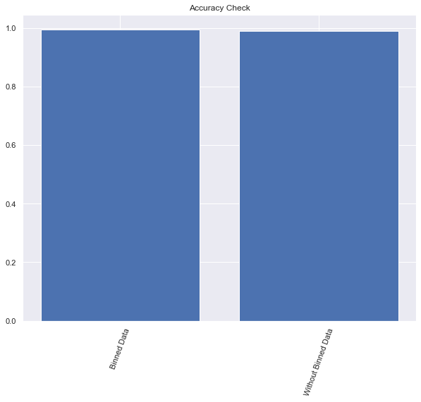

```python
plt.subplots(figsize=(10, 8))
plt.xticks(rotation=70)
plt.title("Accuracy Check")
plt.bar(['Binned Data','Without Binned Data'],[accuracy_score(test_yBin,yBin_pred_LR) , accuracy_score(test_yNoBin,yNoBin_pred_LR)])
```

Logistics Regression Accuracy of Binned Data and with out Binned Data are almost same.

### 2- Decision Tree

#### Applying Decision Tree on Binned Data

```python
DTmodel = DecisionTreeClassifier(criterion = 'entropy')
DTmodel.fit(train_xBin,train_yBin)
yBin_pred_DT = DTmodel.predict(test_xBin)
print(accuracy_score(test_yBin,yBin_pred_DT))
```

```
1.0
```

```python
cmBin_DT=confusion_matrix(test_yBin,yBin_pred_DT)
cmBin_DT
```

```
array([[ 3128,     0],
       [    0, 25808]], dtype=int64)
```

```python
DTBin_tn, DTBin_fp, DTBin_fn, DTBin_tp = confusion_matrix(test_yBin, yBin_pred_DT).ravel()
print(DTBin_tn, DTBin_fp, DTBin_fn, DTBin_tp)
```

```
3128 0 0 25808
```

#### Applying Decision Tree on witout Bined Data

```python
DTmodel = DecisionTreeClassifier(criterion = 'entropy')
DTmodel.fit(train_xNoBin,train_yNoBin)
yNoBin_pred_DT = DTmodel.predict(test_xNoBin)
print(accuracy_score(test_yNoBin,yNoBin_pred_DT))
```

```
1.0
```

```python
cmNoBin_DT=confusion_matrix(test_yNoBin,yNoBin_pred_DT)
cmNoBin_DT
```

```
array([[ 3179,     0],
       [    0, 25757]], dtype=int64)
```

```python
DTNoBin_tn, DTNoBin_fp, DTNoBin_fn, DTNoBin_tp = confusion_matrix(test_yNoBin, yNoBin_pred_DT).ravel()
print(DTNoBin_tn, DTNoBin_fp, DTNoBin_fn, DTNoBin_tp)
```

```
3179 0 0 25757
```

#### Compare Decision Tree Accuracy on Binned and witout Binned Data

```
<BarContainer object of 2 artists>
```

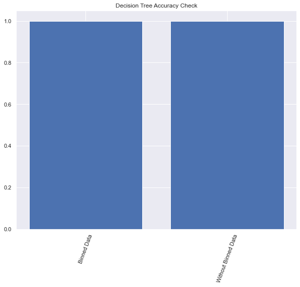

```python
plt.subplots(figsize=(10, 8))
plt.xticks(rotation=70)
plt.title("Decision Tree Accuracy Check")
plt.bar(['Binned Data','Without Binned Data'],[accuracy_score(test_yBin,yBin_pred_DT) , accuracy_score(test_yNoBin,yNoBin_pred_DT)])
```

Accuracy of Decision Tree is 100% on both binned and without Binned Data.

### 3- Random Forest

#### Applying Random Forest on Binned Data

```python
RFmodel=RandomForestClassifier(n_estimators=20)
RFmodel.fit(train_xBin,train_yBin)
yBin_pred_RF = RFmodel.predict(test_xBin)
print(accuracy_score(test_yBin,yBin_pred_RF))
```

```
1.0
```

```python
cmBin_RF=confusion_matrix(test_yBin,yBin_pred_RF)
cmBin_RF
```

```
array([[ 3128,     0],
       [    0, 25808]], dtype=int64)
```

```python
RFBin_tn, RFBin_fp, RFBin_fn, RFBin_tp = confusion_matrix(test_yBin, yBin_pred_RF).ravel()
print(RFBin_tn, RFBin_fp, RFBin_fn, RFBin_tp)
```

```
3128 0 0 25808
```

#### Applying Random Forest on without Binned Data

```python
RFmodel=RandomForestClassifier(n_estimators=20)
RFmodel.fit(train_xNoBin,train_yNoBin)
yNoBin_pred_RF = RFmodel.predict(test_xNoBin)
print(accuracy_score(test_yNoBin,yNoBin_pred_RF))
```

```
0.9999308819463644
```

```python
cmNoBin_RF=confusion_matrix(test_yNoBin,yNoBin_pred_RF)
cmNoBin_RF
```

```
array([[ 3179,     0],
       [    2, 25755]], dtype=int64)
```

```python
RFNoBin_tn, RFNoBin_fp, RFNoBin_fn, RFNoBin_tp = confusion_matrix(test_yNoBin, yNoBin_pred_RF).ravel()
print(RFNoBin_tn, RFNoBin_fp, RFNoBin_fn, RFNoBin_tp)
```

```
3179 0 2 25755
```

#### Compare Random Forest Accuracy on Binned and witout Binned Data

```
<BarContainer object of 2 artists>
```

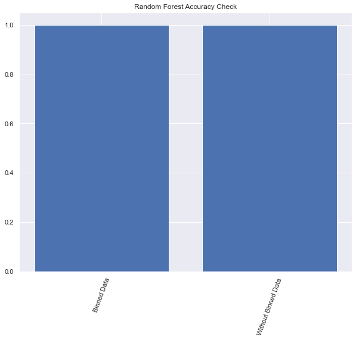

```python
plt.subplots(figsize=(10, 8))
plt.xticks(rotation=70)
plt.title("Random Forest Accuracy Check")
plt.bar(['Binned Data','Without Binned Data'],[accuracy_score(test_yBin,yBin_pred_RF) , accuracy_score(test_yNoBin,yNoBin_pred_RF)])
```

Accuracy of Random Forest is 100% on both binned and without Binned Data.

### 4- SVM

#### Applying SVM on Binned Data

```python
SVMmodel = SVC(kernel='linear')
SVMmodel.fit(train_xBin,train_yBin)
yBin_pred_SVM = SVMmodel.predict(test_xBin)
print(accuracy_score(test_yBin,yBin_pred_SVM))
```

```
0.9982720486591098
```

```python
cmBin_SVM=confusion_matrix(test_yBin,yBin_pred_SVM)
cmBin_SVM
```

```
array([[ 3125,     3],
       [   47, 25761]], dtype=int64)
```

```python
SVMBin_tn, SVMBin_fp, SVMBin_fn, SVMBin_tp = confusion_matrix(test_yBin, yBin_pred_SVM).ravel()
print(SVMBin_tn, SVMBin_fp, SVMBin_fn, SVMBin_tp)
```

```
3125 3 47 25761
```

#### Applying SVM on without Binned Data

```python
SVMmodel = SVC(kernel='linear')
SVMmodel.fit(train_xNoBin,train_yNoBin)
yNoBin_pred_SVM = SVMmodel.predict(test_xNoBin)
print(accuracy_score(test_yNoBin,yNoBin_pred_SVM))
```

```
0.9978918993641139
```

```python
cmNoBin_SVM=confusion_matrix(test_yNoBin,yNoBin_pred_SVM)
cmNoBin_SVM
```

```
array([[ 3178,     1],
       [   60, 25697]], dtype=int64)
```

```python
SVMNoBin_tn, SVMNoBin_fp, SVMNoBin_fn, SVMNoBin_tp = confusion_matrix(test_yNoBin, yNoBin_pred_SVM).ravel()
print(SVMNoBin_tn, SVMNoBin_fp, SVMNoBin_fn, SVMNoBin_tp)
```

```
3178 1 60 25697
```

#### Compare SVM Accuracy on Binned and witout Binned Data

```
<BarContainer object of 2 artists>
```

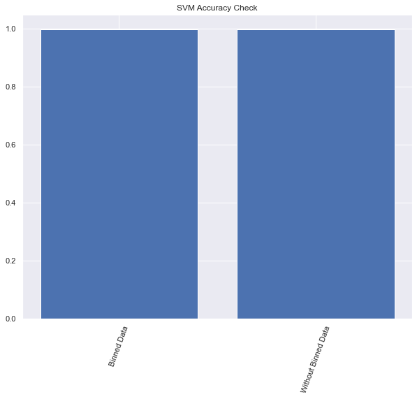

```python
plt.subplots(figsize=(10, 8))
plt.xticks(rotation=70)
plt.title("SVM Accuracy Check")
plt.bar(['Binned Data','Without Binned Data'],[accuracy_score(test_yBin,yBin_pred_SVM) , accuracy_score(test_yNoBin,yNoBin_pred_SVM)])
```

## Performance Measurement Table of "data" Dataset

```python
datatablePerformance = pd.DataFrame(columns=['Dataset','Train Test Ratio','Accuracy','AUC','Specificity','Sensitivity','Precision','F1 score','Prediction error'])
```

```python
datatablePerformance.loc[0] = ['Logistic Regression Binned Data',
             '70/30',
             accuracy_score(test_yBin,yBin_pred_LR),
             roc_auc_score(test_yBin,yBin_pred_LR),
             (LRBin_tn / (LRBin_tn + LRBin_fp)),
             (LRBin_tp / (LRBin_tp + LRBin_fn)),
             (LRBin_tp / (LRBin_tp + LRBin_fp)),
             2 * ((LRBin_tp / (LRBin_tp + LRBin_fp)) * (LRBin_tp / (LRBin_tp + LRBin_fn))) / ((LRBin_tp / (LRBin_tp + LRBin_fp)) + (LRBin_tp / (LRBin_tp + LRBin_fn))),
             LRBin_fn+LRBin_fp
            ]

datatablePerformance.loc[1] = ['Logistic Regression  No Binned Data',
             '70/30',
             accuracy_score(test_yNoBin,yNoBin_pred_LR),
             roc_auc_score(test_yNoBin,yNoBin_pred_LR),
             (LRNoBin_tn / (LRNoBin_tn + LRNoBin_fp)),
             (LRNoBin_tp / (LRNoBin_tp + LRNoBin_fn)),
             (LRNoBin_tp / (LRNoBin_tp + LRNoBin_fp)),
             2 * ((LRNoBin_tp / (LRNoBin_tp + LRNoBin_fp)) * (LRNoBin_tp / (LRNoBin_tp + LRNoBin_fn))) / ((LRNoBin_tp / (LRNoBin_tp + LRNoBin_fp)) + (LRNoBin_tp / (LRNoBin_tp + LRNoBin_fn))),
             LRNoBin_fn+LRNoBin_fp
            ]

datatablePerformance.loc[2] = ['Decision Tree Binnned Data',
             '70/30',
             accuracy_score(test_yBin,yBin_pred_DT),
             roc_auc_score(test_yBin,yBin_pred_DT),
             (DTBin_tn / (DTBin_tn + DTBin_fp)),
             (DTBin_tp / (DTBin_tp + DTBin_fn)),
             (DTBin_tp / (DTBin_tp + DTBin_fp)),
             2 * ((DTBin_tp / (DTBin_tp + DTBin_fp)) * (DTBin_tp / (DTBin_tp + DTBin_fn))) / ((DTBin_tp / (DTBin_tp + DTBin_fp)) + (DTBin_tp / (DTBin_tp + DTBin_fn))),
             DTBin_fn+DTBin_fp
            ]

datatablePerformance.loc[3] = ['Decision Tree No Binnned Data',
             '70/30',
             accuracy_score(test_yNoBin,yNoBin_pred_DT),
             roc_auc_score(test_yNoBin,yNoBin_pred_DT),
             (DTNoBin_tn / (DTNoBin_tn + DTNoBin_fp)),
             (DTNoBin_tp / (DTNoBin_tp + DTNoBin_fn)),
             (DTNoBin_tp / (DTNoBin_tp + DTNoBin_fp)),
             2 * ((DTNoBin_tp / (DTNoBin_tp + DTNoBin_fp)) * (DTNoBin_tp / (DTNoBin_tp + DTNoBin_fn))) / ((DTNoBin_tp / (DTNoBin_tp + DTNoBin_fp)) + (DTNoBin_tp / (DTNoBin_tp + DTNoBin_fn))),
             DTNoBin_fn+DTNoBin_fp
            ]

datatablePerformance.loc[4] = ['Random Forest Binnned Data',
             '70/30',
             accuracy_score(test_yBin,yBin_pred_RF),
             roc_auc_score(test_yBin,yBin_pred_RF),
             (RFBin_tn / (RFBin_tn + RFBin_fp)),
             (RFBin_tp / (RFBin_tp + RFBin_fn)),
             (RFBin_tp / (RFBin_tp + RFBin_fp)),
             2 * ((RFBin_tp / (RFBin_tp + RFBin_fp)) * (RFBin_tp / (RFBin_tp + RFBin_fn))) / ((RFBin_tp / (RFBin_tp + RFBin_fp)) + (RFBin_tp / (RFBin_tp + RFBin_fn))),
             RFBin_fn+RFBin_fp
            ]

datatablePerformance.loc[5] = ['Random Forest No Binnned Data',
             '70/30',
             accuracy_score(test_yNoBin,yNoBin_pred_RF),
             roc_auc_score(test_yNoBin,yNoBin_pred_RF),
             (RFNoBin_tn / (RFNoBin_tn + RFNoBin_fp)),
             (RFNoBin_tp / (RFNoBin_tp + RFNoBin_fn)),
             (RFNoBin_tp / (RFNoBin_tp + RFNoBin_fp)),
             2 * ((RFNoBin_tp / (RFNoBin_tp + RFNoBin_fp)) * (RFNoBin_tp / (RFNoBin_tp + RFNoBin_fn))) / ((RFNoBin_tp / (RFNoBin_tp + RFNoBin_fp)) + (RFNoBin_tp / (RFNoBin_tp + RFNoBin_fn))),
             RFNoBin_fn+RFNoBin_fp
            ]

datatablePerformance.loc[6] = ['SVM Binnned Data',
             '70/30',
             accuracy_score(test_yBin,yBin_pred_SVM),
             roc_auc_score(test_yBin,yBin_pred_SVM),
             (SVMBin_tn / (SVMBin_tn + SVMBin_fp)),
             (SVMBin_tp / (SVMBin_tp + SVMBin_fn)),
             (SVMBin_tp / (SVMBin_tp + SVMBin_fp)),
             2 * ((SVMBin_tp / (SVMBin_tp + SVMBin_fp)) * (SVMBin_tp / (SVMBin_tp + SVMBin_fn))) / ((SVMBin_tp / (SVMBin_tp + SVMBin_fp)) + (SVMBin_tp / (SVMBin_tp + SVMBin_fn))),
             SVMBin_fn+SVMBin_fp
            ]

datatablePerformance.loc[7] = ['SVM No Binnned Data',
             '70/30',
             accuracy_score(test_yNoBin,yNoBin_pred_SVM),
             roc_auc_score(test_yNoBin,yNoBin_pred_SVM),
             (SVMNoBin_tn / (SVMNoBin_tn + SVMNoBin_fp)),
             (SVMNoBin_tp / (SVMNoBin_tp + SVMNoBin_fn)),
             (SVMNoBin_tp / (SVMNoBin_tp + SVMNoBin_fp)),
             2 * ((SVMNoBin_tp / (SVMNoBin_tp + SVMNoBin_fp)) * (SVMNoBin_tp / (SVMNoBin_tp + SVMNoBin_fn))) / ((SVMNoBin_tp / (SVMNoBin_tp + SVMNoBin_fp)) + (SVMNoBin_tp / (SVMNoBin_tp + SVMNoBin_fn))),
             SVMNoBin_fn+SVMNoBin_fp
            ]
```

```python
datatablePerformance
```

|  | Dataset | Train Test Ratio | Accuracy | AUC | Specificity | Sensitivity | Precision | F1 score | Prediction error |
| --- | --- | --- | --- | --- | --- | --- | --- | --- | --- |
| 0 | Logistic Regression Binned Data | 70/30 | 0.995058 | 0.994280 | 0.993286 | 0.995273 | 0.999183 | 0.997224 | 143 |
| 1 | Logistic Regression No Binned Data | 70/30 | 0.990254 | 0.980325 | 0.967600 | 0.993050 | 0.995989 | 0.994518 | 282 |
| 2 | Decision Tree Binnned Data | 70/30 | 1.000000 | 1.000000 | 1.000000 | 1.000000 | 1.000000 | 1.000000 | 0 |
| 3 | Decision Tree No Binnned Data | 70/30 | 1.000000 | 1.000000 | 1.000000 | 1.000000 | 1.000000 | 1.000000 | 0 |
| 4 | Random Forest Binnned Data | 70/30 | 1.000000 | 1.000000 | 1.000000 | 1.000000 | 1.000000 | 1.000000 | 0 |
| 5 | Random Forest No Binnned Data | 70/30 | 0.999931 | 0.999961 | 1.000000 | 0.999922 | 1.000000 | 0.999961 | 2 |
| 6 | SVM Binnned Data | 70/30 | 0.998272 | 0.998610 | 0.999041 | 0.998179 | 0.999884 | 0.999030 | 50 |
| 7 | SVM No Binnned Data | 70/30 | 0.997892 | 0.998678 | 0.999685 | 0.997671 | 0.999961 | 0.998814 | 61 |

#### So Decision Tree and Random Forest 100% Accuracy result.

## Lets work on "df1" dataset

```python
df1.head()
```

| Formatted Date | Summary | Precip Type | Temperature (C) | Apparent Temperature (C) | Humidity | Wind Speed (km/h) | Wind Bearing (degrees) | Visibility (km) | Pressure (millibars) | Binned_Humidity | Binned_Wind_Speed_(km/h) |
| --- | --- | --- | --- | --- | --- | --- | --- | --- | --- | --- | --- |
| 2006-03-31 22:00:00+00:00 | 5 | 0 | 9.472222 | 7.388889 | 0.89 | 14.1197 | 251.0 | 15.8263 | 1015.13 | 2 | 2 |
| 2006-03-31 23:00:00+00:00 | 5 | 0 | 9.355556 | 7.227778 | 0.86 | 14.2646 | 259.0 | 15.8263 | 1015.63 | 2 | 2 |
| 2006-04-01 00:00:00+00:00 | 2 | 0 | 9.377778 | 9.377778 | 0.89 | 3.9284 | 204.0 | 14.9569 | 1015.94 | 2 | 1 |
| 2006-04-01 01:00:00+00:00 | 5 | 0 | 8.288889 | 5.944444 | 0.83 | 14.1036 | 269.0 | 15.8263 | 1016.41 | 2 | 2 |
| 2006-04-01 02:00:00+00:00 | 2 | 0 | 8.755556 | 6.977778 | 0.83 | 11.0446 | 259.0 | 15.8263 | 1016.51 | 2 | 2 |

#### Seperate Data according to Binned data and without Binned Data

```python
df1_withoutBin= df1.drop(['Binned_Wind_Speed_(km/h)','Binned_Humidity'],axis=1)
df1_withBin= df1.drop(['Wind Speed (km/h)','Humidity'],axis=1)
```

```python
df1_withBin.head()
```

| Formatted Date | Summary | Precip Type | Temperature (C) | Apparent Temperature (C) | Wind Bearing (degrees) | Visibility (km) | Pressure (millibars) | Binned_Humidity | Binned_Wind_Speed_(km/h) |
| --- | --- | --- | --- | --- | --- | --- | --- | --- | --- |
| 2006-03-31 22:00:00+00:00 | 5 | 0 | 9.472222 | 7.388889 | 251.0 | 15.8263 | 1015.13 | 2 | 2 |
| 2006-03-31 23:00:00+00:00 | 5 | 0 | 9.355556 | 7.227778 | 259.0 | 15.8263 | 1015.63 | 2 | 2 |
| 2006-04-01 00:00:00+00:00 | 2 | 0 | 9.377778 | 9.377778 | 204.0 | 14.9569 | 1015.94 | 2 | 1 |
| 2006-04-01 01:00:00+00:00 | 5 | 0 | 8.288889 | 5.944444 | 269.0 | 15.8263 | 1016.41 | 2 | 2 |
| 2006-04-01 02:00:00+00:00 | 2 | 0 | 8.755556 | 6.977778 | 259.0 | 15.8263 | 1016.51 | 2 | 2 |

```python
df1_withoutBin.head()
```

| Formatted Date | Summary | Precip Type | Temperature (C) | Apparent Temperature (C) | Humidity | Wind Speed (km/h) | Wind Bearing (degrees) | Visibility (km) | Pressure (millibars) |
| --- | --- | --- | --- | --- | --- | --- | --- | --- | --- |
| 2006-03-31 22:00:00+00:00 | 5 | 0 | 9.472222 | 7.388889 | 0.89 | 14.1197 | 251.0 | 15.8263 | 1015.13 |
| 2006-03-31 23:00:00+00:00 | 5 | 0 | 9.355556 | 7.227778 | 0.86 | 14.2646 | 259.0 | 15.8263 | 1015.63 |
| 2006-04-01 00:00:00+00:00 | 2 | 0 | 9.377778 | 9.377778 | 0.89 | 3.9284 | 204.0 | 14.9569 | 1015.94 |
| 2006-04-01 01:00:00+00:00 | 5 | 0 | 8.288889 | 5.944444 | 0.83 | 14.1036 | 269.0 | 15.8263 | 1016.41 |
| 2006-04-01 02:00:00+00:00 | 2 | 0 | 8.755556 | 6.977778 | 0.83 | 11.0446 | 259.0 | 15.8263 | 1016.51 |

We have to select target class here. In this dataset, we can have two target class  
**1- Summary**  
**2- Precip Type**

First we make **"Precip Type"** as our target class and apply machine learning model on it.

## Precip Type Target Class

#### Split Data to X(Attributes) and Y(Target Class)

```python
xdf1Bin= df1_withBin.drop('Precip Type',axis=1)
ydf1Bin = df1_withBin['Precip Type'].values
```

```python
xdf1NoBin= df1_withoutBin.drop('Precip Type',axis=1)
ydf1NoBin = df1_withoutBin['Precip Type'].values
```

#### Split Data for Training and Testing

```python
train_xdf1Bin,test_xdf1Bin,train_ydf1Bin,test_ydf1Bin = train_test_split(xdf1Bin,ydf1Bin,test_size = 0.3)
train_xdf1NoBin,test_xdf1NoBin,train_ydf1NoBin,test_ydf1NoBin = train_test_split(xdf1NoBin,ydf1NoBin,test_size = 0.3)
```

### 1- Logistic Regression

#### Applying Logistic Regression on Binned Data

```python
LRmodel=LogisticRegression(solver='liblinear')
LRmodel.fit(train_xdf1Bin,train_ydf1Bin)
ydf1Bin_pred_LR = LRmodel.predict(test_xdf1Bin)
print(accuracy_score(test_ydf1Bin,ydf1Bin_pred_LR))
```

```
0.9951617362455073
```

```python
cmdf1Bin_LR=confusion_matrix(test_ydf1Bin,ydf1Bin_pred_LR)
cmdf1Bin_LR
```

```
array([[25606,   112],
       [   28,  3190]], dtype=int64)
```

```python
LRdf1Bin_tn, LRdf1Bin_fp, LRdf1Bin_fn, LRdf1Bin_tp = confusion_matrix(test_ydf1Bin, ydf1Bin_pred_LR).ravel()
print(LRdf1Bin_tn, LRdf1Bin_fp, LRdf1Bin_fn, LRdf1Bin_tp)
```

```
25606 112 28 3190
```

#### Applying Logistic Regression on without Binned Data

```python
LRmodel=LogisticRegression(solver='liblinear')
LRmodel.fit(train_xdf1NoBin,train_ydf1NoBin)
ydf1NoBin_pred_LR = LRmodel.predict(test_xdf1NoBin)
print(accuracy_score(test_ydf1NoBin,ydf1NoBin_pred_LR))
```

```
0.9910492120541885
```

```python
cmdf1NoBin_LR=confusion_matrix(test_ydf1NoBin,ydf1NoBin_pred_LR)
cmdf1NoBin_LR
```

```
array([[25531,   173],
       [   86,  3146]], dtype=int64)
```

```python
LRdf1NoBin_tn, LRdf1NoBin_fp, LRdf1NoBin_fn, LRdf1NoBin_tp = confusion_matrix(test_ydf1NoBin, ydf1NoBin_pred_LR).ravel()
print(LRdf1NoBin_tn, LRdf1NoBin_fp, LRdf1NoBin_fn, LRdf1NoBin_tp)
```

```
25531 173 86 3146
```

#### Compare Logistic Regression Accuracy on Binned and witout Binned Data

```
<BarContainer object of 2 artists>
```

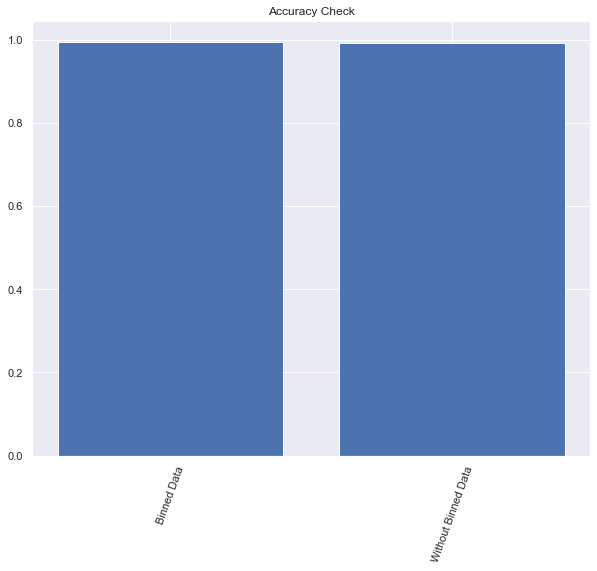

```python
plt.subplots(figsize=(10, 8))
plt.xticks(rotation=70)
plt.title("Accuracy Check")
plt.bar(['Binned Data','Without Binned Data'],[accuracy_score(test_ydf1Bin,ydf1Bin_pred_LR) , accuracy_score(test_ydf1NoBin,ydf1NoBin_pred_LR)])
```

#### Both have alomost same accuracy.

### 2- Decision Tree

#### Applying Decision Tree on Binned Data

```python
DTmodel = DecisionTreeClassifier(criterion = 'entropy')
DTmodel.fit(train_xdf1Bin,train_ydf1Bin)
ydf1Bin_pred_DT = DTmodel.predict(test_xdf1Bin)
print(accuracy_score(test_ydf1Bin,ydf1Bin_pred_DT))
```

```
1.0
```

```python
cmdf1Bin_DT=confusion_matrix(test_ydf1Bin,ydf1Bin_pred_DT)
cmdf1Bin_DT
```

```
array([[25718,     0],
       [    0,  3218]], dtype=int64)
```

```python
DTdf1Bin_tn, DTdf1Bin_fp, DTdf1Bin_fn, DTdf1Bin_tp = confusion_matrix(test_ydf1Bin, ydf1Bin_pred_DT).ravel()
print(DTdf1Bin_tn, DTdf1Bin_fp, DTdf1Bin_fn, DTdf1Bin_tp)
```

```
25718 0 0 3218
```

#### Applying Decision Tree on without Binned Data

```python
DTmodel = DecisionTreeClassifier(criterion = 'entropy')
DTmodel.fit(train_xdf1NoBin,train_ydf1NoBin)
ydf1NoBin_pred_DT = DTmodel.predict(test_xdf1NoBin)
print(accuracy_score(test_ydf1NoBin,ydf1NoBin_pred_DT))
```

```
1.0
```

```python
cmdf1NoBin_DT=confusion_matrix(test_ydf1NoBin,ydf1NoBin_pred_DT)
cmdf1NoBin_DT
```

```
array([[25704,     0],
       [    0,  3232]], dtype=int64)
```

```python
DTdf1NoBin_tn, DTdf1NoBin_fp, DTdf1NoBin_fn, DTdf1NoBin_tp = confusion_matrix(test_ydf1NoBin, ydf1NoBin_pred_DT).ravel()
print(DTdf1NoBin_tn, DTdf1NoBin_fp, DTdf1NoBin_fn, DTdf1NoBin_tp)
```

```
25704 0 0 3232
```

#### Compare Decision Tree Accuracy on Binned and witout Binned Data

```
<BarContainer object of 2 artists>
```

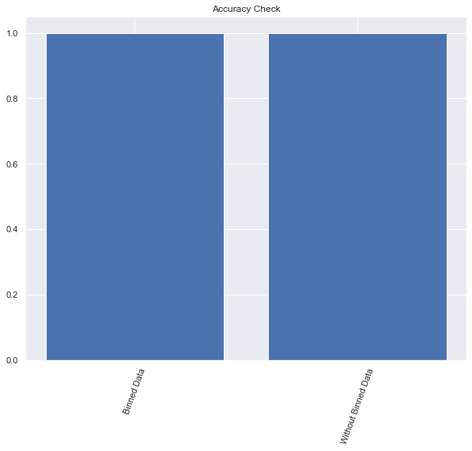

```python
plt.subplots(figsize=(10, 8))
plt.xticks(rotation=70)
plt.title("Accuracy Check")
plt.bar(['Binned Data','Without Binned Data'],[accuracy_score(test_ydf1Bin,ydf1Bin_pred_DT) , accuracy_score(test_ydf1NoBin,ydf1NoBin_pred_DT)])
```

Both have 100% accuracy.

### 3- Random Forest

#### Applying Random Forest on Binned Data

```python
RFmodel=RandomForestClassifier(n_estimators=20)
RFmodel.fit(train_xdf1Bin,train_ydf1Bin)
ydf1Bin_pred_RF = RFmodel.predict(test_xdf1Bin)
print(accuracy_score(test_ydf1Bin,ydf1Bin_pred_RF))
```

```
1.0
```

```python
cmdf1Bin_RF=confusion_matrix(test_ydf1Bin,ydf1Bin_pred_RF)
cmdf1Bin_RF
```

```
array([[25718,     0],
       [    0,  3218]], dtype=int64)
```

```python
RFdf1Bin_tn, RFdf1Bin_fp, RFdf1Bin_fn, RFdf1Bin_tp = confusion_matrix(test_ydf1Bin, ydf1Bin_pred_RF).ravel()
print(RFdf1Bin_tn, RFdf1Bin_fp, RFdf1Bin_fn, RFdf1Bin_tp)
```

```
25718 0 0 3218
```

#### Applying Random Forest on without Binned Data

```python
RFmodel=RandomForestClassifier(n_estimators=20)
RFmodel.fit(train_xdf1NoBin,train_ydf1NoBin)
ydf1NoBin_pred_RF = RFmodel.predict(test_xdf1NoBin)
print(accuracy_score(test_ydf1NoBin,ydf1NoBin_pred_RF))
```

```
1.0
```

```python
cmdf1NoBin_RF=confusion_matrix(test_ydf1NoBin,ydf1NoBin_pred_RF)
cmdf1NoBin_RF
```

```
array([[25704,     0],
       [    0,  3232]], dtype=int64)
```

```python
RFdf1NoBin_tn, RFdf1NoBin_fp, RFdf1NoBin_fn, RFdf1NoBin_tp = confusion_matrix(test_ydf1NoBin, ydf1NoBin_pred_RF).ravel()
print(RFdf1NoBin_tn, RFdf1NoBin_fp, RFdf1NoBin_fn, RFdf1NoBin_tp)
```

```
25704 0 0 3232
```

#### Compare Random Forest Accuracy on Binned and witout Binned Data

```
<BarContainer object of 2 artists>
```

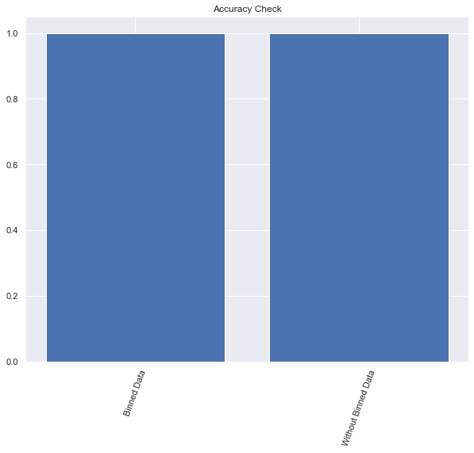

```python
plt.subplots(figsize=(10, 8))
plt.xticks(rotation=70)
plt.title("Accuracy Check")
plt.bar(['Binned Data','Without Binned Data'],[accuracy_score(test_ydf1Bin,ydf1Bin_pred_RF) , accuracy_score(test_ydf1NoBin,ydf1NoBin_pred_RF)])
```

Both have 100% accuracy.

### 4- SVM

#### Applying SVM on Binned Data

```python
SVMmodel = SVC(kernel='linear')
SVMmodel.fit(train_xdf1Bin,train_ydf1Bin)
ydf1Bin_pred_SVM = SVMmodel.predict(test_xdf1Bin)
print(accuracy_score(test_ydf1Bin,ydf1Bin_pred_SVM))
```

```
0.9980646944982029
```

```python
cmdf1Bin_SVM=confusion_matrix(test_ydf1Bin,ydf1Bin_pred_SVM)
cmdf1Bin_SVM
```

```
array([[25662,    56],
       [    0,  3218]], dtype=int64)
```

```python
SVMdf1Bin_tn, SVMdf1Bin_fp, SVMdf1Bin_fn, SVMdf1Bin_tp = confusion_matrix(test_ydf1Bin, ydf1Bin_pred_SVM).ravel()
print(SVMdf1Bin_tn, SVMdf1Bin_fp, SVMdf1Bin_fn, SVMdf1Bin_tp)
```

```
25662 56 0 3218
```

#### Applying SVM on without Binned Data

```python
SVMmodel = SVC(kernel='linear')
SVMmodel.fit(train_xdf1NoBin,train_ydf1NoBin)
ydf1NoBin_pred_SVM = SVMmodel.predict(test_xdf1NoBin)
print(accuracy_score(test_ydf1NoBin,ydf1NoBin_pred_SVM))
```

```
0.9985485208736522
```

```python
cmdf1NoBin_SVM=confusion_matrix(test_ydf1NoBin,ydf1NoBin_pred_SVM)
cmdf1NoBin_SVM
```

```
array([[25663,    41],
       [    1,  3231]], dtype=int64)
```

```python
SVMdf1NoBin_tn, SVMdf1NoBin_fp, SVMdf1NoBin_fn, SVMdf1NoBin_tp = confusion_matrix(test_ydf1NoBin, ydf1NoBin_pred_SVM).ravel()
print(SVMdf1NoBin_tn, SVMdf1NoBin_fp, SVMdf1NoBin_fn, SVMdf1NoBin_tp)
```

```
25663 41 1 3231
```

#### Compare SVM Accuracy on Binned and witout Binned Data

```
<BarContainer object of 2 artists>
```

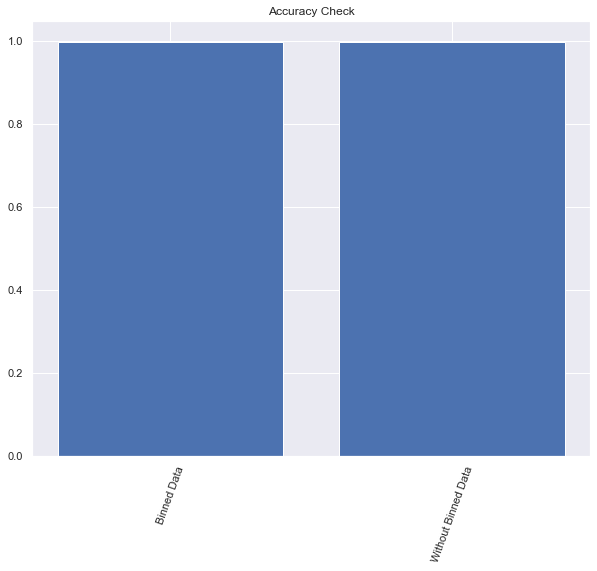

```python
plt.subplots(figsize=(10, 8))
plt.xticks(rotation=70)
plt.title("Accuracy Check")
plt.bar(['Binned Data','Without Binned Data'],[accuracy_score(test_ydf1Bin,ydf1Bin_pred_SVM) , accuracy_score(test_ydf1NoBin,ydf1NoBin_pred_SVM)])
```

Both have almost same accuracy.

## Performance Measurement Table of "df1" Dataset, Target: Precip Type

```python
DTPdf1 = pd.DataFrame(columns=['Dataset','Train Test Ratio','Accuracy','AUC','Specificity','Sensitivity','Precision','F1 score','Prediction error'])
```

```python
DTPdf1.loc[0] = ['Logistic Regression Binned Data',
             '70/30',
             accuracy_score(test_ydf1Bin,ydf1Bin_pred_LR),
             roc_auc_score(test_ydf1Bin,ydf1Bin_pred_LR),
             (LRdf1Bin_tn / (LRdf1Bin_tn + LRdf1Bin_fp)),
             (LRdf1Bin_tp / (LRdf1Bin_tp + LRdf1Bin_fn)),
             (LRdf1Bin_tp / (LRdf1Bin_tp + LRdf1Bin_fp)),
             2 * ((LRdf1Bin_tp / (LRdf1Bin_tp + LRdf1Bin_fp)) * (LRdf1Bin_tp / (LRdf1Bin_tp + LRdf1Bin_fn))) / ((LRdf1Bin_tp / (LRdf1Bin_tp + LRdf1Bin_fp)) + (LRdf1Bin_tp / (LRdf1Bin_tp + LRdf1Bin_fn))),
             LRdf1Bin_fn+LRdf1Bin_fp
            ]

DTPdf1.loc[1] = ['Logistic Regression  No Binned Data',
             '70/30',
             accuracy_score(test_ydf1NoBin,ydf1NoBin_pred_LR),
             roc_auc_score(test_ydf1NoBin,ydf1NoBin_pred_LR),
             (LRdf1NoBin_tn / (LRdf1NoBin_tn + LRdf1NoBin_fp)),
             (LRdf1NoBin_tp / (LRdf1NoBin_tp + LRdf1NoBin_fn)),
             (LRdf1NoBin_tp / (LRdf1NoBin_tp + LRdf1NoBin_fp)),
             2 * ((LRdf1NoBin_tp / (LRdf1NoBin_tp + LRdf1NoBin_fp)) * (LRdf1NoBin_tp / (LRdf1NoBin_tp + LRdf1NoBin_fn))) / ((LRdf1NoBin_tp / (LRdf1NoBin_tp + LRdf1NoBin_fp)) + (LRdf1NoBin_tp / (LRdf1NoBin_tp + LRdf1NoBin_fn))),
             LRdf1NoBin_fn+LRdf1NoBin_fp
            ]

DTPdf1.loc[2] = ['Decision Tree Binned Data',
             '70/30',
             accuracy_score(test_ydf1Bin,ydf1Bin_pred_DT),
             roc_auc_score(test_ydf1Bin,ydf1Bin_pred_DT),
             (DTdf1Bin_tn / (DTdf1Bin_tn + DTdf1Bin_fp)),
             (DTdf1Bin_tp / (DTdf1Bin_tp + DTdf1Bin_fn)),
             (DTdf1Bin_tp / (DTdf1Bin_tp + DTdf1Bin_fp)),
             2 * ((DTdf1Bin_tp / (DTdf1Bin_tp + DTdf1Bin_fp)) * (DTdf1Bin_tp / (DTdf1Bin_tp + DTdf1Bin_fn))) / ((DTdf1Bin_tp / (DTdf1Bin_tp + DTdf1Bin_fp)) + (DTdf1Bin_tp / (DTdf1Bin_tp + DTdf1Bin_fn))),
             DTdf1Bin_fn+DTdf1Bin_fp
            ]

DTPdf1.loc[3] = ['Decision Tree No Binned Data',
             '70/30',
             accuracy_score(test_ydf1NoBin,ydf1NoBin_pred_DT),
             roc_auc_score(test_ydf1NoBin,ydf1NoBin_pred_DT),
             (DTdf1NoBin_tn / (DTdf1NoBin_tn + DTdf1NoBin_fp)),
             (DTdf1NoBin_tp / (DTdf1NoBin_tp + DTdf1NoBin_fn)),
             (DTdf1NoBin_tp / (DTdf1NoBin_tp + DTdf1NoBin_fp)),
             2 * ((DTdf1NoBin_tp / (DTdf1NoBin_tp + DTdf1NoBin_fp)) * (DTdf1NoBin_tp / (DTdf1NoBin_tp + DTdf1NoBin_fn))) / ((DTdf1NoBin_tp / (DTdf1NoBin_tp + DTdf1NoBin_fp)) + (DTdf1NoBin_tp / (DTdf1NoBin_tp + DTdf1NoBin_fn))),
             DTdf1NoBin_fn+DTdf1NoBin_fp
            ]

DTPdf1.loc[4] = ['Randoom Forest Binned Data',
             '70/30',
             accuracy_score(test_ydf1Bin,ydf1Bin_pred_RF),
             roc_auc_score(test_ydf1Bin,ydf1Bin_pred_RF),
             (RFdf1Bin_tn / (RFdf1Bin_tn + RFdf1Bin_fp)),
             (RFdf1Bin_tp / (RFdf1Bin_tp + RFdf1Bin_fn)),
             (RFdf1Bin_tp / (RFdf1Bin_tp + RFdf1Bin_fp)),
             2 * ((RFdf1Bin_tp / (RFdf1Bin_tp + RFdf1Bin_fp)) * (RFdf1Bin_tp / (RFdf1Bin_tp + RFdf1Bin_fn))) / ((RFdf1Bin_tp / (RFdf1Bin_tp + RFdf1Bin_fp)) + (RFdf1Bin_tp / (RFdf1Bin_tp + RFdf1Bin_fn))),
             RFdf1Bin_fn+RFdf1Bin_fp
            ]

DTPdf1.loc[5] = ['Randoom Forest No Binned Data',
             '70/30',
             accuracy_score(test_ydf1NoBin,ydf1NoBin_pred_RF),
             roc_auc_score(test_ydf1NoBin,ydf1NoBin_pred_RF),
             (RFdf1NoBin_tn / (RFdf1NoBin_tn + RFdf1NoBin_fp)),
             (RFdf1NoBin_tp / (RFdf1NoBin_tp + RFdf1NoBin_fn)),
             (RFdf1NoBin_tp / (RFdf1NoBin_tp + RFdf1NoBin_fp)),
             2 * ((RFdf1NoBin_tp / (RFdf1NoBin_tp + RFdf1NoBin_fp)) * (RFdf1NoBin_tp / (RFdf1NoBin_tp + RFdf1NoBin_fn))) / ((RFdf1NoBin_tp / (RFdf1NoBin_tp + RFdf1NoBin_fp)) + (RFdf1NoBin_tp / (RFdf1NoBin_tp + RFdf1NoBin_fn))),
             RFdf1NoBin_fn+RFdf1NoBin_fp
            ]

DTPdf1.loc[6] = ['SVM Binned Data',
             '70/30',
             accuracy_score(test_ydf1Bin,ydf1Bin_pred_SVM),
             roc_auc_score(test_ydf1Bin,ydf1Bin_pred_SVM),
             (SVMdf1Bin_tn / (SVMdf1Bin_tn + SVMdf1Bin_fp)),
             (SVMdf1Bin_tp / (SVMdf1Bin_tp + SVMdf1Bin_fn)),
             (SVMdf1Bin_tp / (SVMdf1Bin_tp + SVMdf1Bin_fp)),
             2 * ((SVMdf1Bin_tp / (SVMdf1Bin_tp + SVMdf1Bin_fp)) * (SVMdf1Bin_tp / (SVMdf1Bin_tp + SVMdf1Bin_fn))) / ((SVMdf1Bin_tp / (SVMdf1Bin_tp + SVMdf1Bin_fp)) + (SVMdf1Bin_tp / (SVMdf1Bin_tp + SVMdf1Bin_fn))),
             SVMdf1Bin_fn+SVMdf1Bin_fp
            ]

DTPdf1.loc[7] = ['SVM No Binned Data',
             '70/30',
             accuracy_score(test_ydf1NoBin,ydf1NoBin_pred_SVM),
             roc_auc_score(test_ydf1NoBin,ydf1NoBin_pred_SVM),
             (SVMdf1NoBin_tn / (SVMdf1NoBin_tn + SVMdf1NoBin_fp)),
             (SVMdf1NoBin_tp / (SVMdf1NoBin_tp + SVMdf1NoBin_fn)),
             (SVMdf1NoBin_tp / (SVMdf1NoBin_tp + SVMdf1NoBin_fp)),
             2 * ((SVMdf1NoBin_tp / (SVMdf1NoBin_tp + SVMdf1NoBin_fp)) * (SVMdf1NoBin_tp / (SVMdf1NoBin_tp + SVMdf1NoBin_fn))) / ((SVMdf1NoBin_tp / (SVMdf1NoBin_tp + SVMdf1NoBin_fp)) + (SVMdf1NoBin_tp / (SVMdf1NoBin_tp + SVMdf1NoBin_fn))),
             SVMdf1NoBin_fn+SVMdf1NoBin_fp
            ]
```

```python
DTPdf1
```

|  | Dataset | Train Test Ratio | Accuracy | AUC | Specificity | Sensitivity | Precision | F1 score | Prediction error |
| --- | --- | --- | --- | --- | --- | --- | --- | --- | --- |
| 0 | Logistic Regression Binned Data | 70/30 | 0.995162 | 0.993472 | 0.995645 | 0.991299 | 0.966081 | 0.978528 | 140 |
| 1 | Logistic Regression No Binned Data | 70/30 | 0.991049 | 0.983330 | 0.993270 | 0.973391 | 0.947876 | 0.960464 | 259 |
| 2 | Decision Tree Binned Data | 70/30 | 1.000000 | 1.000000 | 1.000000 | 1.000000 | 1.000000 | 1.000000 | 0 |
| 3 | Decision Tree No Binned Data | 70/30 | 1.000000 | 1.000000 | 1.000000 | 1.000000 | 1.000000 | 1.000000 | 0 |
| 4 | Randoom Forest Binned Data | 70/30 | 1.000000 | 1.000000 | 1.000000 | 1.000000 | 1.000000 | 1.000000 | 0 |
| 5 | Randoom Forest No Binned Data | 70/30 | 1.000000 | 1.000000 | 1.000000 | 1.000000 | 1.000000 | 1.000000 | 0 |
| 6 | SVM Binned Data | 70/30 | 0.998065 | 0.998911 | 0.997823 | 1.000000 | 0.982896 | 0.991374 | 56 |
| 7 | SVM No Binned Data | 70/30 | 0.998549 | 0.999048 | 0.998405 | 0.999691 | 0.987469 | 0.993542 | 42 |

## Summary Target Class

```python
df1.head()
```

| Formatted Date | Summary | Precip Type | Temperature (C) | Apparent Temperature (C) | Humidity | Wind Speed (km/h) | Wind Bearing (degrees) | Visibility (km) | Pressure (millibars) | Binned_Humidity | Binned_Wind_Speed_(km/h) |
| --- | --- | --- | --- | --- | --- | --- | --- | --- | --- | --- | --- |
| 2006-03-31 22:00:00+00:00 | 5 | 0 | 9.472222 | 7.388889 | 0.89 | 14.1197 | 251.0 | 15.8263 | 1015.13 | 2 | 2 |
| 2006-03-31 23:00:00+00:00 | 5 | 0 | 9.355556 | 7.227778 | 0.86 | 14.2646 | 259.0 | 15.8263 | 1015.63 | 2 | 2 |
| 2006-04-01 00:00:00+00:00 | 2 | 0 | 9.377778 | 9.377778 | 0.89 | 3.9284 | 204.0 | 14.9569 | 1015.94 | 2 | 1 |
| 2006-04-01 01:00:00+00:00 | 5 | 0 | 8.288889 | 5.944444 | 0.83 | 14.1036 | 269.0 | 15.8263 | 1016.41 | 2 | 2 |
| 2006-04-01 02:00:00+00:00 | 2 | 0 | 8.755556 | 6.977778 | 0.83 | 11.0446 | 259.0 | 15.8263 | 1016.51 | 2 | 2 |

Here we use without Binned data, because according the prevoius experience, we can say that binned and with out binned data accuracy is same. So lets split data into x and y.

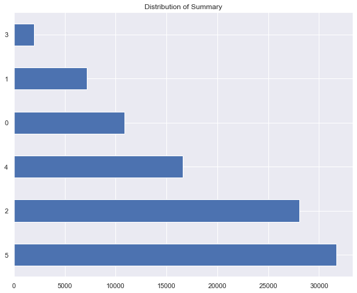

```python
plt.figure(figsize=(10,8))
plt.title('Distribution of Summary')
#df.plot(kind='barh')
df1['Summary'].value_counts().plot(kind='barh')
plt.show()
```

```python
df1['Summary'].value_counts()
```

```
5    31733
2    28094
4    16597
0    10890
1     7148
3     1991
Name: Summary, dtype: int64
```

#### Split Data to X(Attributes) and Y(Target Class)

```python
x = df1.drop(['Summary', 'Binned_Humidity' , 'Binned_Wind_Speed_(km/h)'],axis=1)
y = df1['Summary'].values
```

#### Split Data for Training and Testing

```python
train_x,test_x,train_y,test_y = train_test_split(x,y,test_size = 0.3)
```

### 1- Logistic Regression

#### Apply Logistic Regression and Check Accuracy

```python
LRmodel=LogisticRegression(solver='liblinear')
LRmodel.fit(train_x,train_y)
y_pred_LR = LRmodel.predict(test_x)
print(accuracy_score(test_y,y_pred_LR))
```

```
0.4920859828587227
```

#### Confusion Matrix of Logistic Regression by Crosstab

Cross tab is alternate of confusion matrix. Because we have more then 2 target classes thats why we use that. In diognal we have TP. On column except TP we have FP and on row except TP we have FN for particular class. And rest of the value is TN for particular class.

```python
pd.crosstab(test_y, y_pred_LR, rownames=['Actual Class'], colnames=['Predicted Classs'], margins=True)
```

| Predicted Classs Actual Class | 0 | 1 | 2 | 3 | 4 | 5 | All |
| --- | --- | --- | --- | --- | --- | --- | --- |
| 0 | 6 | 113 | 788 | 2 | 365 | 2008 | 3282 |
| 1 | 0 | 2125 | 1 | 1 | 44 | 0 | 2171 |
| 2 | 2 | 66 | 3251 | 13 | 917 | 4107 | 8356 |
| 3 | 0 | 18 | 83 | 392 | 37 | 52 | 582 |
| 4 | 3 | 168 | 2118 | 10 | 1765 | 890 | 4954 |
| 5 | 3 | 59 | 2236 | 8 | 585 | 6700 | 9591 |
| All | 14 | 2549 | 8477 | 426 | 3713 | 13757 | 28936 |

```python
con_LR = confusion_matrix(test_y, y_pred_LR)
FP_LR = (con_LR.sum(axis=0) - np.diag(con_LR))
FN_LR = (con_LR.sum(axis=1) - np.diag(con_LR))
TP_LR = np.diag(con_LR)
TN_LR = con_LR.sum() - (FP_LR + FN_LR + TP_LR)
print(TP_LR, FN_LR, FP_LR, TN_LR)
```

```
[   6 2125 3251  392 1765 6700] [3276   46 5105  190 3189 2891] [   8  424 5226   34 1948 7057] [25646 26341 15354 28320 22034 12288]
```

### 2- Decision Tree

```python
DTmodel = DecisionTreeClassifier(criterion = 'entropy')
DTmodel.fit(train_x,train_y)
y_pred_DT = DTmodel.predict(test_x)
print(accuracy_score(test_y,y_pred_DT))
```

```
0.49861763892728783
```

#### Confusion Matrix of Decision Tree by Crosstab

```python
pd.crosstab(test_y, y_pred_DT, rownames=['Actual Class'], colnames=['Predicted Classs'], margins=True)
```

| Predicted Classs Actual Class | 0 | 1 | 2 | 3 | 4 | 5 | All |
| --- | --- | --- | --- | --- | --- | --- | --- |
| 0 | 1097 | 3 | 730 | 10 | 337 | 1105 | 3282 |
| 1 | 3 | 2164 | 1 | 3 | 0 | 0 | 2171 |
| 2 | 719 | 0 | 3566 | 28 | 1463 | 2580 | 8356 |
| 3 | 7 | 10 | 25 | 467 | 26 | 47 | 582 |
| 4 | 314 | 0 | 1425 | 20 | 2358 | 837 | 4954 |
| 5 | 1242 | 0 | 2676 | 24 | 873 | 4776 | 9591 |
| All | 3382 | 2177 | 8423 | 552 | 5057 | 9345 | 28936 |

```python
con_DT = confusion_matrix(test_y, y_pred_DT)
FP_DT = (con_DT.sum(axis=0) - np.diag(con_DT))
FN_DT = (con_DT.sum(axis=1) - np.diag(con_DT))
TP_DT = np.diag(con_DT)
TN_DT = con_DT.sum() - (FP_LR + FN_LR + TP_LR)
print(TP_DT, FN_DT, FP_DT, TN_DT)
```

```
[1097 2164 3566  467 2358 4776] [2185    7 4790  115 2596 4815] [2285   13 4857   85 2699 4569] [25646 26341 15354 28320 22034 12288]
```

### 3- Random Forest

```python
RFmodel=RandomForestClassifier(n_estimators=20)
RFmodel.fit(train_x,train_y)
y_pred_RF = RFmodel.predict(test_x)
print(accuracy_score(test_y,y_pred_RF))
```

```
0.5660077412220071
```

#### Confusion Matrix of Random Forest by Crosstab

```python
pd.crosstab(test_y, y_pred_RF, rownames=['Actual Class'], colnames=['Predicted Classs'], margins=True)
```

| Predicted Classs Actual Class | 0 | 1 | 2 | 3 | 4 | 5 | All |
| --- | --- | --- | --- | --- | --- | --- | --- |
| 0 | 972 | 5 | 653 | 1 | 243 | 1408 | 3282 |
| 1 | 0 | 2171 | 0 | 0 | 0 | 0 | 2171 |
| 2 | 323 | 0 | 4224 | 30 | 1075 | 2704 | 8356 |
| 3 | 4 | 9 | 29 | 497 | 15 | 28 | 582 |
| 4 | 126 | 0 | 1466 | 22 | 2746 | 594 | 4954 |
| 5 | 644 | 0 | 2652 | 7 | 520 | 5768 | 9591 |
| All | 2069 | 2185 | 9024 | 557 | 4599 | 10502 | 28936 |

```python
con_RF = confusion_matrix(test_y, y_pred_RF)
FP_RF = (con_RF.sum(axis=0) - np.diag(con_RF))
FN_RF = (con_RF.sum(axis=1) - np.diag(con_RF))
TP_RF = np.diag(con_RF)
TN_RF = con_RF.sum() - (FP_LR + FN_LR + TP_LR)
print(TP_RF, FN_RF, FP_RF, TN_RF)
```

```
[ 972 2171 4224  497 2746 5768] [2310    0 4132   85 2208 3823] [1097   14 4800   60 1853 4734] [25646 26341 15354 28320 22034 12288]
```

### Performance Measurement , Target Class: Summary

```python
from sklearn import tree, metrics
from sklearn.preprocessing import label_binarize
from sklearn.multiclass import OneVsRestClassifier
from sklearn import preprocessing
def multiclass_roc_auc_score(y_test, y_pred, average="macro"):
    lb = preprocessing.LabelBinarizer()
    lb.fit(y_test)
    y_test = lb.transform(y_test)
    y_pred = lb.transform(y_pred)
    return metrics.roc_auc_score(y_test, y_pred, average=average)
```

```python
ptable = pd.DataFrame(columns=['Dataset','Train Test Ratio','Accuracy','AUC','Specificity','Sensitivity','Precision','F1 score','Prediction error'])
```

```python
ptable.loc[0] = ['Logistic Regression',
             '70/30',
             accuracy_score(test_y,y_pred_LR),
             multiclass_roc_auc_score(test_y, y_pred_LR),
             sum(TN_LR)/(sum(TN_LR)+sum(FP_LR)),
             sum(TP_LR)/(sum(TP_LR)+sum(FN_LR)),
             sum(TP_LR)/(sum(TP_LR)+sum(FP_LR)),
             2 * ((sum(TP_LR) / (sum(TP_LR) + sum(FP_LR))) * (sum(TP_LR) / (sum(TP_LR) + sum(FN_LR)))) / ((sum(TP_LR) / (sum(TP_LR) + sum(FP_LR))) + (sum(TP_LR) / (sum(TP_LR) + sum(FN_LR)))),
             sum(FN_LR)+sum(FP_LR)
            ]

ptable.loc[1] = ['Random Forest',
             '70/30',
             accuracy_score(test_y,y_pred_RF),
             multiclass_roc_auc_score(test_y, y_pred_RF),
             sum(TN_RF)/(sum(TN_RF)+sum(FP_RF)),
             sum(TP_RF)/(sum(TP_RF)+sum(FN_RF)),
             sum(TP_RF)/(sum(TP_RF)+sum(FP_RF)),
             2 * ((sum(TP_RF) / (sum(TP_RF) + sum(FP_RF))) * (sum(TP_RF) / (sum(TP_RF) + sum(FN_RF)))) / ((sum(TP_RF) / (sum(TP_RF) + sum(FP_RF))) + (sum(TP_RF) / (sum(TP_RF) + sum(FN_RF)))),
             sum(FN_RF)+sum(FP_RF)
            ]

ptable.loc[2] = ['Decision Tree',
             '70/30',
             accuracy_score(test_y,y_pred_DT),
             multiclass_roc_auc_score(test_y, y_pred_DT),
             sum(TN_DT)/(sum(TN_DT)+sum(FP_DT)),
             sum(TP_DT)/(sum(TP_DT)+sum(FN_DT)),
             sum(TP_DT)/(sum(TP_DT)+sum(FP_DT)),
             2 * ((sum(TP_DT) / (sum(TP_DT) + sum(FP_DT))) * (sum(TP_DT) / (sum(TP_DT) + sum(FN_DT)))) / ((sum(TP_DT) / (sum(TP_DT) + sum(FP_DT))) + (sum(TP_DT) / (sum(TP_DT) + sum(FN_DT)))),
             sum(FN_DT)+sum(FP_DT)
            ]
```

```python
ptable
```

|  | Dataset | Train Test Ratio | Accuracy | AUC | Specificity | Sensitivity | Precision | F1 score | Prediction error |
| --- | --- | --- | --- | --- | --- | --- | --- | --- | --- |
| 0 | Logistic Regression | 70/30 | 0.492086 | 0.698398 | 0.898417 | 0.492086 | 0.492086 | 0.492086 | 29394 |
| 1 | Random Forest | 70/30 | 0.566008 | 0.767558 | 0.911899 | 0.566008 | 0.566008 | 0.566008 | 25116 |
| 2 | Decision Tree | 70/30 | 0.498618 | 0.738071 | 0.899592 | 0.498618 | 0.498618 | 0.498618 | 29016 |